# ML2 Team 1 Presentation 2

```r
[385] "V330"           "V331"           "V332"           "V333"
[389] "V334"           "V335"           "V336"           "V337"
[393] "V338"           "V339"
```

A lot of columns- No good desc on what many of them do

```r
Trans<-Trans[,1:55] # cut out "V" fields
Iden <- read.csv("D:/Downloads/train_identity.csv")
head(Iden,20)
   TransactionID id_01  id_02 id_03 id_04 id_05 id_06 id_07 id_08 id_09 id_10  id_11
1        2987004     0  70787    NA    NA    NA    NA    NA    NA    NA    NA 100.00
2        2987008    -5  98945    NA    NA     0    -5    NA    NA    NA    NA 100.00
3        2987010    -5 191631     0     0     0     0    NA    NA     0     0 100.00
4        2987011    -5 221832    NA    NA     0    -6    NA    NA    NA    NA 100.00
5        2987016     0   7460     0     0     1     0    NA    NA     0     0 100.00
6        2987017    -5  61141     3     0     3     0    NA    NA     3     0 100.00
7        2987022   -15     NA    NA    NA    NA    NA    NA    NA    NA    NA     NA
8        2987038     0  31964     0     0     0   -10    NA    NA     0     0 100.00
9        2987040   -10 116098     0     0     0     0    NA    NA     0     0 100.00
10       2987048    -5 257037    NA    NA     0     0    NA    NA    NA    NA 100.00
11       2987049    -5 287959    NA    NA     1   -11    NA    NA    NA    NA 100.00
12       2987057     0  88525    NA    NA    NA    NA    NA    NA    NA    NA 100.00
13       2987066    -5  54927     0     0     0    -1    NA    NA     0     0 100.00
14       2987069     0  69542     0     0     2    -4    NA    NA     0     0 100.00
15       2987070     0 132356    NA    NA     1    -6    NA    NA    NA    NA 100.00
16       2987072     0 275611    NA    NA     0     0    NA    NA    NA    NA 100.00
17       2987074    -5 419136    NA    NA     0     0    NA    NA    NA    NA 100.00
18       2987084    -5 436352    NA    NA     0     0    NA    NA    NA    NA 100.00
19       2987093    -5  34810    NA    NA     1     0    NA    NA     0     0  93.75
20       2987099   -10 129080     0     0     9   -43    22   -34     0     0 100.00
      id_12 id_13 id_14 id_15    id_16 id_17 id_18 id_19 id_20 id_21 id_22
1  NotFound    NA  -480   New NotFound   166    NA   542   144    NA    NA
2  NotFound    49  -300   New NotFound   166    NA   621   500    NA    NA
3  NotFound    52    NA Found    Found   121    NA   410   142    NA    NA
4  NotFound    52    NA   New NotFound   225    NA   176   507    NA    NA
5  NotFound    NA  -300 Found    Found   166    15   529   575    NA    NA
6  NotFound    52  -300 Found    Found   166    18   529   600    NA    NA
7  NotFound    14    NA                   NA    NA    NA    NA    NA    NA
8     Found    NA  -300 Found    Found   166    15   352   533    NA    NA
9  NotFound    52    NA Found    Found   121    NA   410   142    NA    NA
10 NotFound    52    NA   New NotFound   225    NA   484   507    NA    NA
11 NotFound    52    NA   New NotFound   225    NA   254   507    NA    NA
12 NotFound    NA  -300   New NotFound   166    NA   278   600    NA    NA
13 NotFound    52  -360 Found    Found   166    NA   307   333    NA    NA
14    Found    NA  -300 Found    Found   166    15   352   533    NA    NA
15 NotFound    NA  -300   New NotFound   166    13   529   549    NA    NA
16 NotFound    20    NA   New NotFound   225    NA   266   566    NA    NA
17 NotFound    52    NA   New NotFound   225    NA   266   305    NA    NA
18 NotFound    52    NA   New NotFound   225    NA   290   401    NA    NA
19 NotFound    52  -300   New NotFound   166    NA   548   391    NA    NA
20    Found    49  -300 Found    Found   166    12   122   549   252    14
                  id_23 id_24 id_25 id_26 id_27 id_28    id_29            id_30
1                          NA    NA    NA         New NotFound      Android 7.0
2                          NA    NA    NA         New NotFound       iOS 11.1.2
3                          NA    NA    NA       Found    Found
4                          NA    NA    NA         New NotFound
5                          NA    NA    NA       Found    Found Mac OS X 10_11_6
6                          NA    NA    NA       Found    Found       Windows 10
7                          NA    NA    NA
8                          NA    NA    NA       Found    Found          Android
9                          NA    NA    NA       Found    Found
10                         NA    NA    NA         New NotFound
11                         NA    NA    NA         New NotFound
12                         NA    NA    NA         New NotFound      Android 7.0
13                         NA    NA    NA       Found    Found       Windows 10
14                         NA    NA    NA       Found    Found            Linux
15                         NA    NA    NA         New NotFound       iOS 11.1.2
16                         NA    NA    NA         New NotFound
17                         NA    NA    NA         New NotFound
18                         NA    NA    NA         New NotFound
19                         NA    NA    NA       Found    Found       Windows 10
20 IP_PROXY:TRANSPARENT    11   321   184 Found Found    Found       iOS 11.0.3
                     id_31 id_32     id_33          id_34 id_35 id_36 id_37 id_38
1      samsung browser 6.2    32 2220x1080 match_status:2  TRUE FALSE  TRUE  TRUE
2       mobile safari 11.0    32  1334x750 match_status:1  TRUE FALSE FALSE  TRUE
3              chrome 62.0    NA                          FALSE FALSE  TRUE  TRUE
4              chrome 62.0    NA                          FALSE FALSE  TRUE  TRUE
5              chrome 62.0    24  1280x800 match_status:2  TRUE FALSE  TRUE  TRUE
6              chrome 62.0    24  1366x768 match_status:2  TRUE FALSE  TRUE  TRUE
7                             NA                             NA    NA    NA    NA
8              chrome 62.0    32 1920x1080 match_status:2  TRUE FALSE  TRUE  TRUE
9              chrome 62.0    NA                          FALSE FALSE  TRUE  TRUE
10             chrome 62.0    NA                          FALSE FALSE  TRUE  TRUE
11             chrome 62.0    NA                          FALSE FALSE  TRUE  TRUE
12 chrome 62.0 for android    32 1920x1080 match_status:2  TRUE FALSE  TRUE  TRUE
13             chrome 62.0    24 1680x1050 match_status:2  TRUE FALSE  TRUE  TRUE
14             chrome 62.0    32 1920x1080 match_status:2  TRUE FALSE  TRUE  TRUE
15      mobile safari 11.0    32  1136x640 match_status:1  TRUE FALSE  TRUE  TRUE
16 chrome 62.0 for android    NA                          FALSE FALSE  TRUE  TRUE
17             chrome 62.0    NA                          FALSE FALSE  TRUE  TRUE
18             chrome 62.0    NA                          FALSE FALSE  TRUE  TRUE
19               edge 15.0    24           match_status:2  TRUE FALSE  TRUE  TRUE
20   mobile safari generic    32  1334x750 match_status:2  TRUE FALSE  TRUE FALSE
   DeviceType                    DeviceInfo
1      mobile SAMSUNG SM-G892A Build/NRD90M
2      mobile                    iOS Device
3     desktop                       Windows
4     desktop
5     desktop                         MacOS
6     desktop                       Windows
7
8      mobile
9     desktop                       Windows
10    desktop                       Windows
11    desktop                       Windows
12     mobile         SM-G930V Build/NRD90M
13    desktop                       Windows
14    desktop
15     mobile                    iOS Device
16     mobile       BLADE A602 Build/MRA58K
17    desktop                       Windows
18    desktop                       Windows
19    desktop                       Windows
20     mobile                    iOS Device
```

**Adding Info for device. Get most comon Device type**

```r
library(dplyr)
library(tidyr)
```

From Top team -> card1,addr1, and D1

```r
User<-Trans %>% select(TransactionID,card1, addr1, D1)
Device<- Iden %>% select(TransactionID,DeviceType,DeviceInfo)
```

we now have linking fields on transaction ID to join Identity to the User Table

```r
SummaryTable_USER_DEVICE <-left_join(User, Device, by = "TransactionID")
```

Replacing null values with “Unknown”

```r
SummaryTable_USER_DEVICE<- SummaryTable_USER_DEVICE %>% mutate(DeviceInfo = replace_na(DeviceInfo, "UnKNOWN")) %>%
  mutate(DeviceInfo= replace(DeviceInfo,DeviceInfo=="", "UnKNOWN")) %>% mutate(DeviceType = replace_na(DeviceType, "UnKNOWN")) %>%
  mutate(DeviceType= replace(DeviceType,DeviceType=="", "UnKNOWN"))
```

Creating a surrogate key for user id

```r
OneKey<- filter(SummaryTable_USER_DEVICE,DeviceInfo!="UnKNOWN") %>% unite(User,'card1','addr1','D1',sep='|')%>%
  unite(Device,'DeviceType','DeviceInfo',sep='|')
```

```r
MostCommon<- OneKey %>% group_by(User)%>% count(Device) %>% slice(which.max(1))
```

Taking only the linking data and # user

```r
MostCommon<- MostCommon %>% select('User','Device')
```

Joining data back to most common and one key which has trasnaction ID

```r
Joined<-  left_join(OneKey, MostCommon, by = "User")
```

Seeing if the device in the transaction matches the most common for the user

```r
TranMatched<- Joined %>% mutate(Matched= (Device.x==Device.y))
```

Taking only the transaction ID and the resulting boolean

```r
TranMatched<- TranMatched%>% select('TransactionID','Matched')
```

**Getting Back to Transactions**

```r
Trans$card4<-as.factor(Trans$card4) #Master Visa Etc.

Trans$isFraud<-as.factor(Trans$isFraud) #Binary Class

Trans$ProductCD <-as.factor(Trans$ProductCD ) #Product type
```

Creating Boolean for email domain matching or True if second domain is blank (bill to and send to are the same)

```r
WorkingTrans<- Trans  %>%
  mutate(EmailsMatch=((P_emaildomain)==(R_emaildomain)| R_emaildomain==''))
```

Convert to factor

```r
WorkingTrans$EmailsMatch<- as.factor(WorkingTrans$EmailsMatch)
```

Select fields

```r
FirstDataSet<- WorkingTrans %>% select('TransactionID','isFraud','TransactionAmt','ProductCD','card1','card2','card3','card4','card5','card6'
                                       ,'addr1','addr2','EmailsMatch')
```

Join our matching information on device

```r
JoinedSet<- left_join(FirstDataSet, TranMatched, by = "TransactionID")
```

Matched as factor

```r
JoinedSet$Matched<- as.factor(JoinedSet$Matched)
```

Final output

```r
Output_SET_1<- JoinedSet %>% select('isFraud','TransactionAmt','ProductCD','card1','card2','card3','card4','card5','card6'
                                    ,'addr1','addr2','EmailsMatch','Matched')
```

### Ridge

```r
library(glmnet)
Loading required package: Matrix

Attaching package: 'Matrix'
The following objects are masked from 'package:tidyr':

    expand, pack, unpack
Loaded glmnet 4.1
```

Make sure is fraud is a factor for binary classification

```r
Output_SET_1$isFraud<-as.factor(Output_SET_1$isFraud)
```

Fixing sparse factors where small occurence types exist

```r
Output_SET_1<-Output_SET_1%>% mutate(Matched = replace_na(Matched, FALSE)) %>% mutate(card6 = replace(card6,card6=='charge card','credit')) %>%
  mutate(card6 = replace(card6,card6=='debit or credit','debit')) %>%  mutate(card6 = replace(card6,card6=='','credit'))

summary(Output_SET_1)
 isFraud    TransactionAmt     ProductCD      card1           card2
 0:569877   Min.   :    0.25   C: 68519   Min.   : 1000   Min.   :100.0
 1: 20663   1st Qu.:   43.32   H: 33024   1st Qu.: 6019   1st Qu.:214.0
            Median :   68.77   R: 37699   Median : 9678   Median :361.0
            Mean   :  135.03   S: 11628   Mean   : 9899   Mean   :362.6
            3rd Qu.:  125.00   W:439670   3rd Qu.:14184   3rd Qu.:512.0
            Max.   :31937.39              Max.   :18396   Max.   :600.0
                                                          NA's   :8933
     card3                    card4            card5          card6
 Min.   :100.0                   :  1577   Min.   :100.0   Length:590540
 1st Qu.:150.0   american express:  8328   1st Qu.:166.0   Class :character
 Median :150.0   discover        :  6651   Median :226.0   Mode  :character
 Mean   :153.2   mastercard      :189217   Mean   :199.3
 3rd Qu.:150.0   visa            :384767   3rd Qu.:226.0
 Max.   :231.0                             Max.   :237.0
 NA's   :1565                              NA's   :4259
     addr1           addr2       EmailsMatch     Matched
 Min.   :100.0   Min.   : 10.0   FALSE: 34787   FALSE:540777
 1st Qu.:204.0   1st Qu.: 87.0   TRUE :555753   TRUE : 49763
 Median :299.0   Median : 87.0
 Mean   :290.7   Mean   : 86.8
 3rd Qu.:330.0   3rd Qu.: 87.0
 Max.   :540.0   Max.   :102.0
 NA's   :65706   NA's   :65706
```

Re casting it to factor

```r
Output_SET_1$card6<-as.factor(as.character(Output_SET_1$card6)) #Credit/Debit
```

Perform mean replacement for other numeric fields if na

```r
for(i in 1:ncol(Output_SET_1)){
  Output_SET_1[is.na(Output_SET_1[,i]), i] <- mean(Output_SET_1[,i], na.rm = TRUE)
}


summary(Output_SET_1)
 isFraud    TransactionAmt     ProductCD      card1           card2
 0:569877   Min.   :    0.25   C: 68519   Min.   : 1000   Min.   :100.0
 1: 20663   1st Qu.:   43.32   H: 33024   1st Qu.: 6019   1st Qu.:215.0
            Median :   68.77   R: 37699   Median : 9678   Median :361.0
            Mean   :  135.03   S: 11628   Mean   : 9899   Mean   :362.6
            3rd Qu.:  125.00   W:439670   3rd Qu.:14184   3rd Qu.:512.0
            Max.   :31937.39              Max.   :18396   Max.   :600.0
     card3                    card4            card5          card6
 Min.   :100.0                   :  1577   Min.   :100.0   credit:150572
 1st Qu.:150.0   american express:  8328   1st Qu.:166.0   debit :439968
 Median :150.0   discover        :  6651   Median :226.0
 Mean   :153.2   mastercard      :189217   Mean   :199.3
 3rd Qu.:150.0   visa            :384767   3rd Qu.:226.0
 Max.   :231.0                             Max.   :237.0
     addr1           addr2       EmailsMatch     Matched
 Min.   :100.0   Min.   : 10.0   FALSE: 34787   FALSE:540777
 1st Qu.:205.0   1st Qu.: 87.0   TRUE :555753   TRUE : 49763
 Median :290.7   Median : 87.0
 Mean   :290.7   Mean   : 86.8
 3rd Qu.:327.0   3rd Qu.: 87.0
 Max.   :540.0   Max.   :102.0
```

Split data

```r
set.seed(2021)
LenData<-nrow(Output_SET_1)
Test.Index<-sample(1:LenData*.8)
```

Create Train and Test Sets

```r
Train<-Output_SET_1[Test.Index,]
Test<- Output_SET_1[-Test.Index,]
```

Create x Matrix

```r
x_train <- model.matrix( ~ .-1, Train[,2:ncol(Train)])
summary(Output_SET_1)
 isFraud    TransactionAmt     ProductCD      card1           card2
 0:569877   Min.   :    0.25   C: 68519   Min.   : 1000   Min.   :100.0
 1: 20663   1st Qu.:   43.32   H: 33024   1st Qu.: 6019   1st Qu.:215.0
            Median :   68.77   R: 37699   Median : 9678   Median :361.0
            Mean   :  135.03   S: 11628   Mean   : 9899   Mean   :362.6
            3rd Qu.:  125.00   W:439670   3rd Qu.:14184   3rd Qu.:512.0
            Max.   :31937.39              Max.   :18396   Max.   :600.0
     card3                    card4            card5          card6
 Min.   :100.0                   :  1577   Min.   :100.0   credit:150572
 1st Qu.:150.0   american express:  8328   1st Qu.:166.0   debit :439968
 Median :150.0   discover        :  6651   Median :226.0
 Mean   :153.2   mastercard      :189217   Mean   :199.3
 3rd Qu.:150.0   visa            :384767   3rd Qu.:226.0
 Max.   :231.0                             Max.   :237.0
     addr1           addr2       EmailsMatch     Matched
 Min.   :100.0   Min.   : 10.0   FALSE: 34787   FALSE:540777
 1st Qu.:205.0   1st Qu.: 87.0   TRUE :555753   TRUE : 49763
 Median :290.7   Median : 87.0
 Mean   :290.7   Mean   : 86.8
 3rd Qu.:327.0   3rd Qu.: 87.0
 Max.   :540.0   Max.   :102.0
```

Create label vector

```r
Y.Train<-Train[,1]
```

Create test matrix and labels

```r
x_test <- model.matrix( ~ .-1, Test[,2:ncol(Test)])
Y.Test<-Test[,1]
```

Create grid of lambdas

```r
lambdas <- 10^seq(3, -2, by = -1)
```

Fit GLM

```r
GLM_FIT <- cv.glmnet(x_train, Y.Train, alpha = 0, lambda = lambdas,family='binomial')
summary(GLM_FIT)
           Length Class  Mode
lambda      6     -none- numeric
cvm         6     -none- numeric
cvsd        6     -none- numeric
cvup        6     -none- numeric
cvlo        6     -none- numeric
nzero       6     -none- numeric
call        6     -none- call
name        1     -none- character
glmnet.fit 13     lognet list
lambda.min  1     -none- numeric
lambda.1se  1     -none- numeric
index       2     -none- numeric
```

Get best Lambda

```r
best_lambda <- GLM_FIT$lambda[which.min(GLM_FIT$cvm)]
best_lambda
[1] 0.01
```

Create best model

```r
Best_Ridge<- glmnet(x_train, Y.Train, alpha = 0, lambda = best_lambda,family='binomial')
```

Predict class (.5 threshold)

```r
preds<-predict(Best_Ridge,newx = x_test,type = 'class')
table(preds,Y.Test)
     Y.Test
preds      0      1
    0 114044   4064
```

Get raw prediction values

```r
predsVal<-predict(Best_Ridge,newx = x_test)
```

Plot AUC

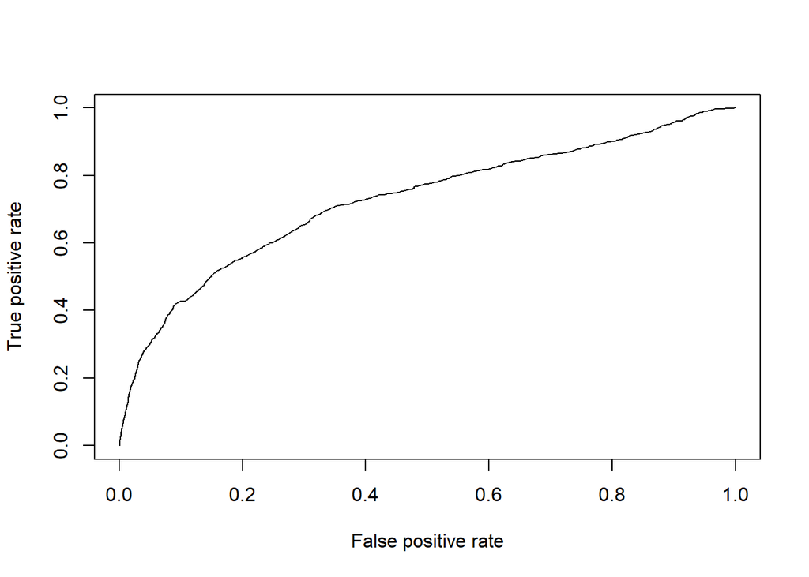

```r
library(ROCR)
Ridge_AUCThing <- prediction(predsVal,Y.Test, label.ordering = c(0,1))
Ridge_Chart <- performance(Ridge_AUCThing,"tpr", "fpr")
plot(Ridge_Chart)
```

Get AUC value

```r
auc_ROCR <- performance(Ridge_AUCThing, measure = "auc")
auc_ROCR <- auc_ROCR@y.values[[1]]
auc_ROCR # [1] 0.726611
[1] 0.726611
```

### Lasso

Fit Lasso model

```r
GLM_FIT_LASSO <- cv.glmnet(x_train, Y.Train, alpha = 1, lambda = lambdas,family='binomial',trainControl='cv')
summary(GLM_FIT_LASSO)
           Length Class  Mode
lambda      6     -none- numeric
cvm         6     -none- numeric
cvsd        6     -none- numeric
cvup        6     -none- numeric
cvlo        6     -none- numeric
nzero       6     -none- numeric
call        7     -none- call
name        1     -none- character
glmnet.fit 13     lognet list
lambda.min  1     -none- numeric
lambda.1se  1     -none- numeric
index       2     -none- numeric
```

Best lambda

```r
best_lambda <- GLM_FIT_LASSO$lambda[which.min(GLM_FIT_LASSO$cvm)]
best_lambda
[1] 0.01
```

Best model

```r
Best_Lasso<- glmnet(x_train, Y.Train, alpha = 1, lambda = best_lambda,family='binomial')
```

Basic predictions

```r
preds<-predict(Best_Lasso,newx = x_test,type = 'class')
table(preds,Y.Test)
     Y.Test
preds      0      1
    0 114044   4064
```

Raw Predcitions

```r
predsVal_Lasso<-predict(Best_Lasso,newx = x_test)
```

Plot AUC

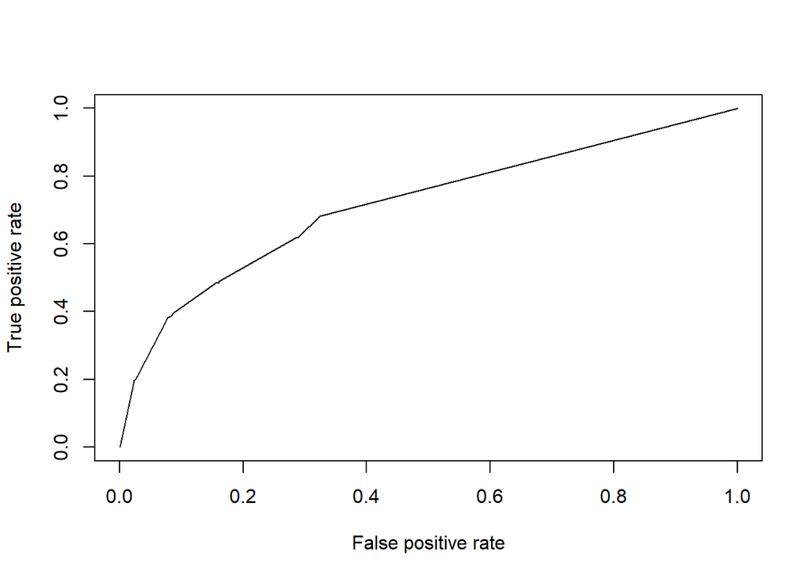

```r
library(ROCR)
Lasso_AUCThing <- prediction(predsVal_Lasso,Y.Test, label.ordering = c(0,1))
Lasso_Chart <- performance(Lasso_AUCThing,"tpr", "fpr")
plot(Lasso_Chart)
```

Get AUC value

```r
auc_ROCR <- performance(Lasso_AUCThing, measure = "auc")
auc_ROCR <- auc_ROCR@y.values[[1]]
auc_ROCR # [1] 0.7265185 # on new run 0.7165336
[1] 0.7165336
```